# Exploratory Data Analaysis on Titanic dataset

2024/05/22 by *Wei Gen*

#### 1. Import the required libraries

Import Pandas and Matplotlib pacakges for data manuplication and visualization.

```python
import pandas as pd
import matplotlib.pyplot as plt
```

Pandas is a package to manage table type dataset. Matplotlib is a package to show and visualize different kinds of charts.

#### 2. Load the dataset

```python
df = pd.read_csv('titanic_1.csv')
print(df)
```

```
     PassengerId  Survived  Pclass  \
0              1         0       3
1              2         1       1
2              3         1       3
3              4         1       1
4              5         0       3
..           ...       ...     ...
886          887         0       2
887          888         1       1
888          889         0       3
889          890         1       1
890          891         0       3

                                                  Name     Sex   Age  SibSp  \
0                              Braund, Mr. Owen Harris    male  22.0      1
```

[output cut: 25 more lines]

##### Explain what the command does and mean:

1) We load and read the Titanic dataset from a CSV file named 'titanic_1.csv' into a Pandas DataFrame

##### Explanation of the output:

1) The output of the code will show the Titanic data and user will be able to view it clearly.

#### 3. Data exploration

Display the first few rows of the dataset to understand its structure. Print information about the columns and their data types. Show summary statistics for numerical columns (e.g., mean, min, max, etc.).

```python
# Show the first few rows of the data to understand its structure
print(df.head())

# Print information about the columns and their data types
print(df.info())

# Show summary statistics for numerical columns (e.g., mean, min, max, etc.).
print(df.describe())
```

```
   PassengerId  Survived  Pclass  \
0            1         0       3
1            2         1       1
2            3         1       3
3            4         1       1
4            5         0       3

                                                Name     Sex   Age  SibSp  \
0                            Braund, Mr. Owen Harris    male  22.0      1
1  Cumings, Mrs. John Bradley (Florence Briggs Th...  female  38.0      1
2                             Heikkinen, Miss. Laina  female  26.0      0
3       Futrelle, Mrs. Jacques Heath (Lily May Peel)  female  35.0      1
4                           Allen, Mr. William Henry    male  35.0      0

   Parch            Ticket     Fare Cabin Embarked
0      0         A/5 21171   7.2500   NaN        S
1      0          PC 17599  71.2833   C85        C
2      0  STON/O2. 3101282   7.9250   NaN        S
3      0            113803  53.1000  C123        S
4      0            373450   8.0500   NaN        S
<class 'pandas.core.frame.DataFrame'>
RangeIndex: 891 entries, 0 to 890
Data columns (total 12 columns):
 #   Column       Non-Null Count  Dtype
---  ------       --------------  -----
 0   PassengerId  891 non-null    int64
 1   Survived     891 non-null    int64
 2   Pclass       891 non-null    int64
 3   Name         891 non-null    object
 4   Sex          891 non-null    object
 5   Age          891 non-null    float64
 6   SibSp        891 non-null    int64
 7   Parch        891 non-null    int64
 8   Ticket       891 non-null    object
 9   Fare         891 non-null    float64
 10  Cabin        204 non-null    object
 11  Embarked     889 non-null    object
dtypes: float64(2), int64(5), object(5)
memory usage: 83.7+ KB
None
       PassengerId    Survived      Pclass         Age       SibSp  \
count   891.000000  891.000000  891.000000  891.000000  891.000000
mean    446.000000    0.383838    2.308642   29.361582    0.523008
std     257.353842    0.486592    0.836071   13.019697    1.102743
min       1.000000    0.000000    1.000000    0.420000    0.000000
25%     223.500000    0.000000    2.000000   22.000000    0.000000
50%     446.000000    0.000000    3.000000   28.000000    0.000000
75%     668.500000    1.000000    3.000000   35.000000    1.000000
max     891.000000    1.000000    3.000000   80.000000    8.000000

            Parch        Fare
count  891.000000  891.000000
mean     0.381594   32.204208
std      0.806057   49.693429
min      0.000000    0.000000
25%      0.000000    7.910400
50%      0.000000   14.454200
75%      0.000000   31.000000
max      6.000000  512.329200
```

##### Explain what the command does and means :

1) The df.head() shows the first five rows of the data and for us to understand the structure.

2) The info() method prints information about the DataFrame. The information contains the number of columns, column labels, column data types, memory usage, range index, and the number of cells in each column (non-null values).

3) Pandas describe() is used to view some basic statistical details like percentile, mean, std, etc. of a data frame or a series of numeric values.

##### Explanation of the output :

1) The command df.head() means showing the head of the data which mean the first five rows.

2) The info() means means showing all the information of the dataframe. The information contains the number of columns, column labels, column data types, memory usage, range index, and the number of cells in each column (non-null values).

3) The describe() code allows user to view (as per output) some basic statistical details like percentile, mean, std, etc. of a data frame or a series of numeric values.

### 4. Data cleaning

Identify and handle missing values in the dataset (e.g., fill missing age values with median). Perform any necessary data transformations or cleaning steps.

```python
# Identify the missing values

print('Number of missing values per column:')

print(df.isnull().sum())

# Calcualate the median age

median_age = df['Age'].median()

print('Median age before missing values:', median_age)

# Fill missing age values with the median age

df['Age'] = df['Age'].fillna(median_age)
```

```
Number of missing values per column:
PassengerId      0
Survived         0
Pclass           0
Name             0
Sex              0
Age              0
SibSp            0
Parch            0
Ticket           0
Fare             0
Cabin          687
Embarked         2
dtype: int64
Median age before missing values: 28.0
```

##### Explain what the command does and means

1) print(df.isnull().sum()): This command calculates the total number of missing values in each column of the DataFrame 'df' and prints the result.

2) df['Age'].median(): This line calculates the median agge from the 'Age' column of the DataFrame.

3) df['Age'].fillna(median_age)`: This command fills the missing values in the 'Age' column of the DataFrame with the calculated median age.

#### 5. Data analysis

Calculate and display the count of passengers by gender. Compute the average age of passengers. Determine the survival rate by passenger class.

```python
# Calculate and display the count of passengers by gender.

print('Count of passengers by gender:')

print(df['Sex'].value_counts())

# Calculate the average age of the passenger

print('Average age of passengers:')

print(df['Age'].mean())

 # Survival rate by passenger class

print('Survival rate by passenger class')

survival_rate = df.groupby('Pclass')['Survived'].mean()

print(survival_rate)
```

```
Count of passengers by gender:
Sex
male      577
female    314
Name: count, dtype: int64
Average age of passengers:
29.36158249158249
Survival rate by passenger class
Pclass
1    0.629630
2    0.472826
3    0.242363
Name: Survived, dtype: float64
```

##### Explain what the code does and means

1) print('Count of passengers by gender:'): This line prints a message indicating that the following output will show the count of passengers by gender.

- print(df['Sex'].value_counts()): This command calculates and prints the count of passengers for each gender category ('male' and 'female') in the DataFrame. It utilizes the 'value_counts()' method to count the occurrences of each unique value in the 'Sex' column.

2) Average age of passengers:

- print('Average age of passengers:'): This line prints a message indicating that the following output will display the average age of passengers.
- print(df['Age'].mean()): This command calculates and prints the average (mean) age of all passengers in the DataFrame. It calculates the mean value of the 'Age' column.

3) Survival rate by passenger class:

- 'print('Survival rate by passenger class')': This line prints a message indicating that the following output will show the survival rate by passenger class.
- 'survival_rate = df.groupby('Pclass')['Survived'].mean(): This command calculates the survival rate for each passenger class ('Pclass') in the DataFrame. It groups the DataFrame by the 'Pclass' column and then calculates the mean of the 'Survived' column within each group.
- 'print(survival_rate)': This command prints the calculated survival rates for each passenger class.

##### Explanation of the output

1) Count of Passengers by Gender: This part of the output displays the number of passengers categorized by gender ('male' and 'female') in the dataset.

2) Average Age of Passengers: This section provides the average age of all passengers in the dataset, indicating the typical age of a passenger on average.

3) Survival Rate by Passenger Class: This part of the output shows the survival rates for passengers based on their class ('Pclass'). It indicates the percentage of passengers who survived within each class category, giving insight into how survival chances varied across different classes.

#### 6. Data visualization

Create a bar chart to visualize the survival rate by passenger class. Add appropriate labels and a title to the chart.

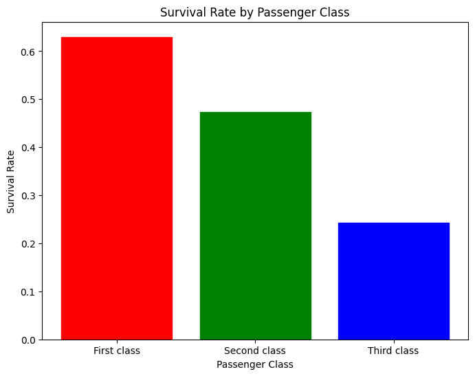

```python
import matplotlib.pyplot as plt

import pandas as pd

# Calculate the mean survival rate by passenger class

survival_rates = df.groupby('Pclass')['Survived'].mean()

# Create a bar chart

plt.figure(figsize=(8, 6))

bar = plt.bar(survival_rates.index, survival_rates.values)

# Change the color of each bar

bar[0].set_color('red')    # First class

bar[1].set_color('green')  # Second class

bar[2].set_color('blue')   # Third class

 # Add title and labels

plt.title('Survival Rate by Passenger Class')

plt.xlabel('Passenger Class')

plt.ylabel('Survival Rate')

plt.xticks(survival_rate.index,['First class','Second class','Third class'])

# Display the plot

plt.show()
```

##### Explain what the code does and means

1. Calculate the Mean Survival Rate by Passenger Class:
   - survival_rates = df.groupby('Pclass')['Survived'].mean()': Groups data by 'Pclass' and calculates the average survival rate for each class.
2. Create a Bar Chart:
   - plt.figure(figsize=(8, 6)): Initializes a new plot with dimensions 8x6 inches.
   - bar = plt.bar(survival_rates.index, survival_rates.values): Plots a bar chart with passenger classes on the x-axis and survival rates on the y-axis.
3. Change Bar Colors:
   - bar[0].set_color('red'): Sets the first bar (first class) to red.
   - bar[1].set_color('green'): Sets the second bar (second class) to green.
   - bar[2].set_color('blue'): Sets the third bar (third class) to blue.
4. Add Title and Labels:
   - plt.title('Survival Rate by Passenger Class'): Adds a title to the plot.
   - plt.xlabel('Passenger Class'): Labels the x-axis.
   - plt.ylabel('Survival Rate'): Labels the y-axis.
   - plt.xticks(survival_rate.index, ['First class', 'Second class', 'Third class']): Customizes x-axis labels.
5. Display the Plot:
   - plt.show(): Able to see the designed chart

##### Explanation of the output

1) After entering the code, user able to view a complete graph of the survival rate by passenger class. There are three colors of the bar colors indicatres different passenger class. The chart shows different survival rate for each passenger classes after the calculation of the mean.

#### 7. Conclusion

Summarize your findings or insights gained from analyzing the Titanic dataset.

##### Explantion

Performing data analysis with Pandas allows us to gain valuable insights from datasets like the Titanic dataset. By following this step-by-step guide, we explored the dataset, cleaned the data, visualised key patterns and derived meaningful insights using these powerful libraries. The flexibility and rich functionality of Pandas make them an essential tool for any data analyst or scientist.